# NEP 10K ROMS grid

Alberto Rovellini

12/8/2022

This document shows details on how handle the NEP 10K NetCDF grid file used to map physical variables to GOA-CLIM models. Motivation for this is that we discovered a mismatch between ROMS bathymetry and the 1000 m isobath of the mask that we obtained from clipping the NMFS areas shapefile with the [ETOPO depth raster](https://www.ngdc.noaa.gov/mgg/global/relief/ETOPO1/data/bedrock/cell_registered/netcdf/) (see `NMFS_mgmt_area_mask_builder.Rmd` for details). The mismatch occurred along the GOA continental slope, where the depth of ~10% of the ROMS points that were mapped to areas shallower than the 1000 m isobath was greater than 1000 m.

We explored three possible reasons for this mismatch:

1. We are using the wrong projection for the ROMS grid, mapping the rho points to incorrect spatial coordinates when we match the grid to the NMFS areas mask.
2. We are not calculating the depth of the 42 layers correctly with our custom version of `angstroms::romshcoords`.
3. There is a mismatch between the bathymetry datasets used by ROMS and by our NMFS mask.

```r
pacman::p_load(tidyverse, tidync, sf, rnaturalearth, raster, data.table, maps, mapdata, angstroms, viridis, tabularaster, dtplyr)
select <- dplyr::select
```

This is the grid file for NEP 10K. Also read in the shapefile for the NMFS areas.

```r
romsfile_grid <- "../Data/ROMS/NEP_grid_5a.nc"
roms_grid <- tidync(romsfile_grid)
nmfs_areas <- read_sf('../Data/NMFS management area shapefiles/gf95_nmfs.shp')
```

# Projection

Get variables. We do not need water velocity, so we can ignore u and v points.

```r
# Grid info
grid_variables <- hyper_grids(roms_grid) %>% # all available grids in the ROMS ncdf
  pluck("grid") %>% # for each grid, pull out all the variables asssociated with that grid and make a reference table
  purrr::map_df(function(x){
    roms_grid %>% activate(x) %>% hyper_vars() %>%
      mutate(grd=x)
  })
grid_variables$name
```

```
##  [1] "hraw"      "rdrg_grid" "x_psi"     "y_psi"     "lat_psi"   "lon_psi"
##  [7] "mask_psi"  "h"         "f"         "pm"        "pn"        "dndx"
## [13] "dmde"      "x_rho"     "y_rho"     "lat_rho"   "lon_rho"   "mask_rho"
## [19] "angle"     "x_u"       "y_u"       "lat_u"     "lon_u"     "mask_u"
## [25] "x_v"       "y_v"       "lat_v"     "lon_v"     "mask_v"    "xl"
## [31] "el"        "PLONG"     "ROTA"      "P1"        "P2"        "P3"
## [37] "P4"        "XOFF"      "YOFF"      "depthmin"  "depthmax"  "spherical"
## [43] "f0"        "dfdy"      "JPRJ"      "PLAT"      "JLTS"
```

```r
# Find appropriate ROMS ncdf grid for the rho points
latlon_rhogrd <- grid_variables %>% filter(name=="lat_rho") %>% pluck('grd')
# pull the lon/lats
roms_rho <- roms_grid %>%
  activate(latlon_rhogrd) %>%
  hyper_tibble() %>%
  dplyr::select(lon_rho,lat_rho,xi_rho,eta_rho,h) %>%
  mutate(rhoidx=row_number()) # add index
```

Now turn the data to spatial. First, assign to the coordinates a generic CRS, like EPSG:4326.

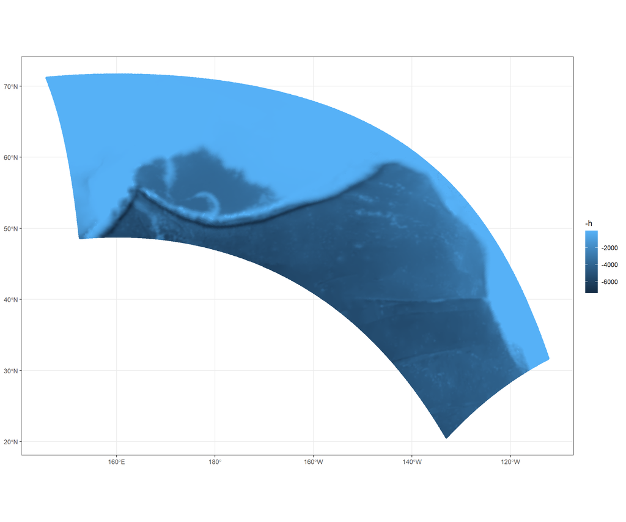

```r
# turn to spatial with crs 4326
roms_sf <- roms_rho %>% st_as_sf(coords = c('lon_rho','lat_rho'), crs = 4326) #set as spatial data with a standard CRS

ggplot()+
  geom_sf(data = roms_sf, aes(color = -h))+
  theme_bw()
```

Now view in the native projection from the grid. From al Hermann: *The values in the grid netcdf file indicate that the original grid was derived using a Lambert conformal conic projection. Reference latitudes are 40n and 60n; reference longitude is 210e.*

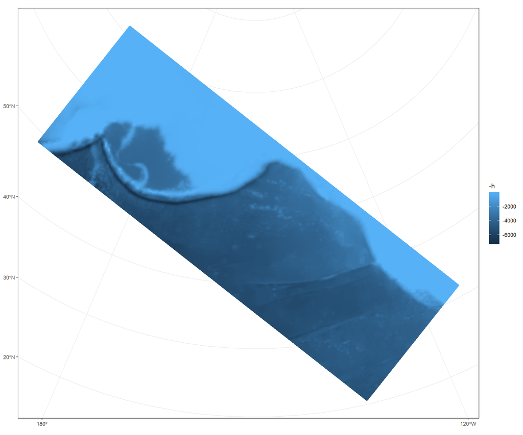

```r
lcc_crs <- st_crs("+proj=lcc +lat_1=40 +lat_2=60 +lon_0=210") # set CRS based on information from Al

roms_lcc <- roms_sf %>% st_transform(crs = lcc_crs)

ggplot()+
  geom_sf(data = roms_lcc, aes(color = -h))+
  theme_bw()
```

Now reproject to the CRS of the NMFS areas shapefile.

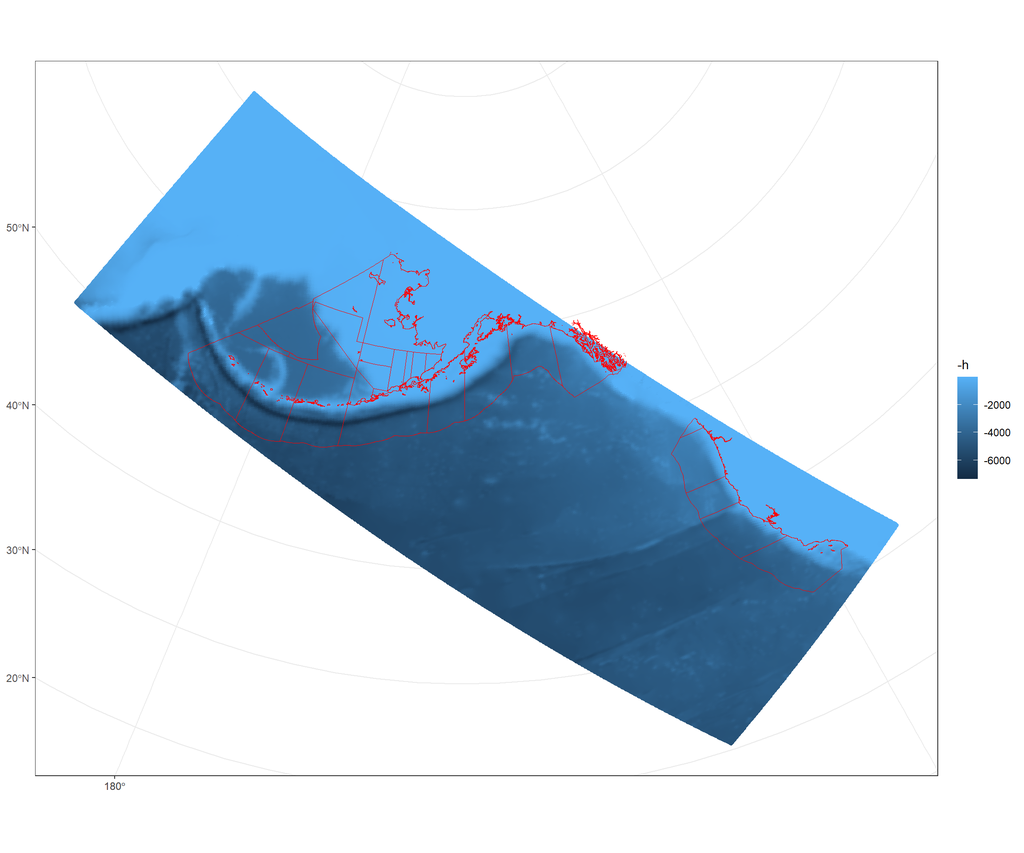

```r
roms_to_nmfs <- roms_lcc %>%
  st_transform(crs = st_crs(nmfs_areas))

ggplot()+
  geom_sf(data=roms_to_nmfs, aes(color = -h))+
  geom_sf(data=nmfs_areas, fill = NA, color = 'red')+
  theme_bw()
```

And how would this compare to cutting out the LCC step?

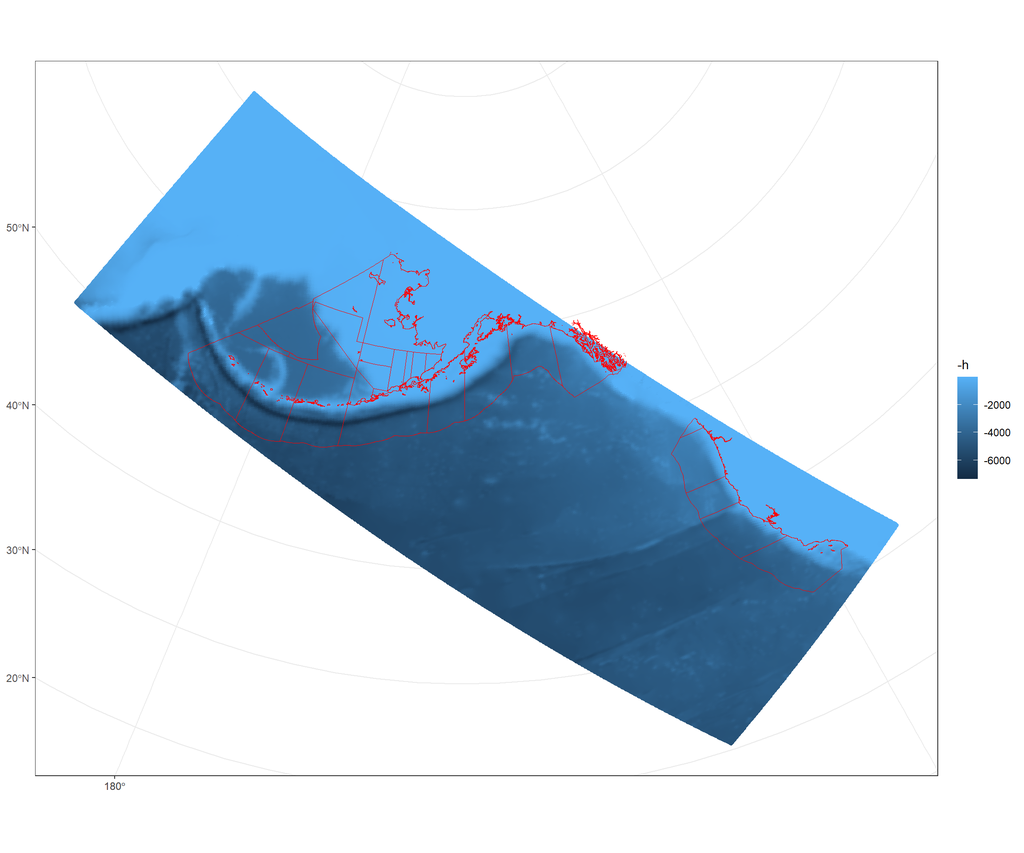

```r
roms_sf %>%
  st_transform(crs = st_crs(nmfs_areas)) %>%
  ggplot()+
  geom_sf(aes(color = -h))+
  geom_sf(data=nmfs_areas, fill = NA, color = 'red')+
  theme_bw()
```

In conclusion: When reprojecting lat and lon from the NEP 10K NetCDF grid, you first need to assign to them a generic CRS, like `EPSG:4326`. Then you can transform the grid (now a spatial object) to the target CRS. If you want to visualize the gird, you can project it to LCC with this string: `"+proj=lcc +lat_1=40 +lat_2=60 +lon_0=210"`.

In `ROMS_coordinate_mapping.Rmd` we assign EPSG:4326 to the coordinates of the rho points before reprojecting them to the CRS of the NMFS areas shapefile. So everything looks good there, and we can rule out cause 1.

# Depth

The method we adapted from `angstroms` calculates depth of the ROMS layers that are identical to the values in the Z-grid file provided by Al Hermann, so we can rule out cause 2.

To address this issue, we simply filter out ROMS points that have h>1000, abandoning the clipping of NMFS areas by 1000 m isobath.

Let’s see what this looks like.

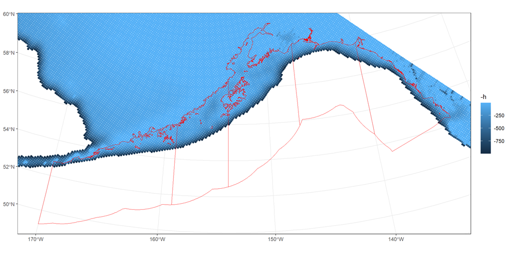

```r
nmfs_areas_goa <- nmfs_areas %>%
  filter(NMFS_AREA %in% c(610,620,630,640,650))%>% # subset to 610-650
  filter(GF95_NMFS1 %in% c(186,194,259,585,870)) # Removes inter-coastal in SE AK

nmfs_bbox <- st_bbox(nmfs_areas_goa)

roms_to_nmfs %>%
  filter(h <= 1000) %>%
  ggplot()+
  geom_sf(aes(color = -h))+
  geom_sf(data = nmfs_areas_goa, fill = NA, color = 'red')+
  coord_sf(xlim = c(nmfs_bbox$xmin, nmfs_bbox$xmax), ylim = c(nmfs_bbox$ymin, nmfs_bbox$ymax))+
  theme_bw()
```